# PCIT-CoS-Waitlist RCT Paper 1: CCQ LSAC Self-Efficacy

Nancy Briggs

27 May 2022

### CCQ LSAC Self-Efficacy

Output run on 2022-05-31

#### Descriptives

| group | time | n | mean | sd | median | min | max |
| --- | --- | --- | --- | --- | --- | --- | --- |
| 1 | 1 | 30 | 3.767 | 1.073 | 4.0 | 0 | 5 |
| 1 | 2 | 23 | 4.130 | 0.815 | 4.0 | 2 | 5 |
| 1 | 3 | 18 | 3.778 | 1.060 | 4.0 | 1 | 5 |
| 2 | 1 | 28 | 3.571 | 1.034 | 3.0 | 2 | 5 |
| 2 | 2 | 12 | 3.500 | 0.798 | 3.5 | 2 | 5 |
| 2 | 3 | 4 | 4.000 | 0.816 | 4.0 | 3 | 5 |
| 3 | 1 | 24 | 3.792 | 1.103 | 4.0 | 2 | 5 |
| 3 | 2 | 22 | 3.727 | 1.032 | 4.0 | 2 | 5 |
| 3 | 3 | 0 | NaN | NA | NA | Inf | -Inf |

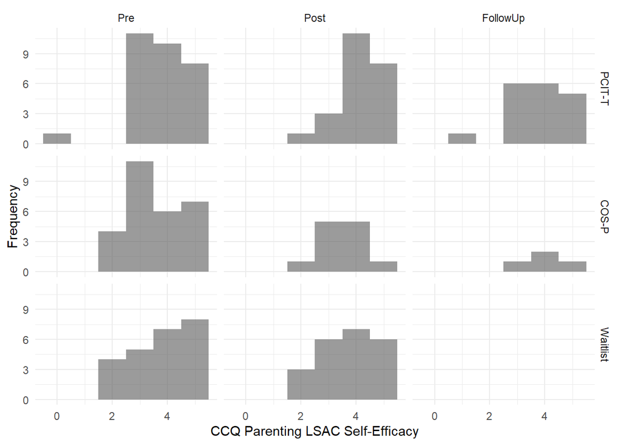

#### Model & Results

A linear mixed model with random effect for individual and fixed effects of group, time and the interaction was run. Estimated marginal means were obtained, and contrasts specified to test Hypothesis 1 and Hypothesis 2.

```
## fixed-effect model matrix is rank deficient so dropping 1 column / coefficient
```

```
## refitting model(s) with ML (instead of REML)
```

|  | Effect | npar | AIC | BIC | logLik | deviance | Chisq | Df | Pr(>Chisq) |
| --- | --- | --- | --- | --- | --- | --- | --- | --- | --- |
| result0 | Intercept | 3 | 434.423 | 443.668 | -214.212 | 428.423 | NA | NA | NA |
| result1 | Group | 5 | 435.937 | 451.344 | -212.968 | 425.937 | 2.487 | 2 | 0.288 |
| result2 | Time | 7 | 439.351 | 460.921 | -212.675 | 425.351 | 0.586 | 2 | 0.746 |
| result3 | Group*Time | 10 | 441.978 | 472.792 | -210.989 | 421.978 | 3.373 | 3 | 0.338 |

```r
summary(result3)
```

```
## Linear mixed model fit by REML. t-tests use Satterthwaite's method [
## lmerModLmerTest]
## Formula: outcome ~ group * time + (1 | id)
##    Data: dat
##
## REML criterion at convergence: 432.3
##
## Scaled residuals:
##     Min      1Q  Median      3Q     Max
## -4.9508 -0.3665  0.0547  0.4550  2.3931
##
## Random effects:
##  Groups   Name        Variance Std.Dev.
##  id       (Intercept) 0.5954   0.7716
##  Residual             0.4470   0.6685
## Number of obs: 161, groups:  id, 84
##
## Fixed effects:
##               Estimate Std. Error        df t value Pr(>|t|)
## (Intercept)    3.76667    0.18640 111.40423  20.207   <2e-16 ***
## group2        -0.19524    0.26828 111.40423  -0.728   0.4683
## group3         0.05596    0.27767 114.95989   0.202   0.8406
## time2          0.32320    0.19172  76.14765   1.686   0.0959 .
## time3          0.09024    0.21007  77.93511   0.430   0.6687
## group2:time2  -0.54424    0.31957  84.15711  -1.703   0.0922 .
## group3:time2  -0.29628    0.28072  76.99086  -1.055   0.2945
## group2:time3  -0.05365    0.45943  85.71630  -0.117   0.9073
## ---
## Signif. codes:  0 '***' 0.001 '**' 0.01 '*' 0.05 '.' 0.1 ' ' 1
##
## Correlation of Fixed Effects:
##             (Intr) group2 group3 time2  time3  grp2:2 grp3:2
## group2      -0.695
## group3      -0.671  0.466
## time2       -0.417  0.290  0.280
## time3       -0.380  0.264  0.255  0.419
## group2:tim2  0.250 -0.360 -0.168 -0.600 -0.252
## group3:tim2  0.285 -0.198 -0.444 -0.683 -0.286  0.410
## group2:tim3  0.174 -0.250 -0.117 -0.192 -0.457  0.307  0.131
## fit warnings:
## fixed-effect model matrix is rank deficient so dropping 1 column / coefficient
```

#### Estimated Means & Change

Estimated means for each Treatment and Time are presented. In addition, within-group change between time points is presented with 95% CIs.

##### Group mean difference at each timepoint

Effect sizes all calculated by the pooled T1 SD of the outcome. Adjusted p-value from Bonferroni correction.

Group Differences at Each Time Point

| Group Difference | Time | Mean | SE | t | p | adj p | Lower CL | Upper CL | Effect Size | Lower CL | Upper CL |
| --- | --- | --- | --- | --- | --- | --- | --- | --- | --- | --- | --- |
| 1 - 2 | 1 | 0.195 | 0.268 | 0.728 | 0.748 | 1.000 | -0.442 | 0.832 | 0.185 | -0.299 | 0.733 |
| 1 - 3 | 1 | -0.056 | 0.278 | -0.201 | 0.978 | 1.000 | -0.715 | 0.603 | -0.053 | -0.538 | 0.512 |
| 2 - 3 | 1 | -0.251 | 0.282 | -0.890 | 0.648 | 1.000 | -0.921 | 0.419 | -0.238 | -0.767 | 0.317 |
| 1 - 2 | 2 | 0.739 | 0.336 | 2.199 | 0.075 | 0.088 | -0.057 | 1.536 | 0.702 | 0.097 | 1.409 |
| 1 - 3 | 2 | 0.240 | 0.295 | 0.815 | 0.694 | 1.000 | -0.459 | 0.939 | 0.228 | -0.345 | 0.844 |
| 2 - 3 | 2 | -0.499 | 0.341 | -1.463 | 0.312 | 0.437 | -1.307 | 0.309 | -0.474 | -1.149 | 0.140 |
| 1 - 2 | 3 | 0.249 | 0.473 | 0.527 | 0.858 | 1.000 | -0.871 | 1.368 | 0.236 | -0.653 | 1.191 |
| 1 - 3 | 3 | NA | NA | NA | NA | NA | NA | NA | NA | NA | NA |
| 2 - 3 | 3 | NA | NA | NA | NA | NA | NA | NA | NA | NA | NA |

* Effect size scaled by pooled T1 SD  
† ES 95% Bootstrapped Percentile CI limits  
‡ If you want a positive ES (and it is calculated as negative), be sure to switch the signs and positions of the lower and upper CIs.

##### Change within each group

Within-Group Change and Effect Sizes

| Change | Group | Mean | SE | t | p | adj p | Lower CL | Upper CL | Effect Size | Lower CL | Upper CL |
| --- | --- | --- | --- | --- | --- | --- | --- | --- | --- | --- | --- |
| 1 - 2 | 1 | -0.323 | 0.192 | -1.683 | 0.218 | 0.289 | -0.782 | 0.135 | -0.307 | -0.685 | 0.088 |
| 1 - 3 | 1 | -0.090 | 0.211 | -0.429 | 0.904 | 1.000 | -0.593 | 0.412 | -0.086 | -0.492 | 0.338 |
| 2 - 3 | 1 | 0.233 | 0.217 | 1.072 | 0.534 | 0.861 | -0.286 | 0.752 | 0.221 | -0.215 | 0.655 |
| 1 - 2 | 2 | 0.221 | 0.257 | 0.860 | 0.667 | 1.000 | -0.391 | 0.833 | 0.210 | -0.268 | 0.697 |
| 1 - 3 | 2 | -0.037 | 0.411 | -0.089 | 0.996 | 1.000 | -1.015 | 0.942 | -0.035 | -0.845 | 0.782 |
| 2 - 3 | 2 | -0.258 | 0.421 | -0.612 | 0.814 | 1.000 | -1.262 | 0.747 | -0.244 | -1.112 | 0.617 |
| 1 - 2 | 3 | -0.027 | 0.205 | -0.131 | 0.991 | 1.000 | -0.517 | 0.464 | -0.026 | -0.454 | 0.340 |
| 1 - 3 | 3 | NA | NA | NA | NA | NA | NA | NA | NA | NA | NA |
| 2 - 3 | 3 | NA | NA | NA | NA | NA | NA | NA | NA | NA | NA |

* Effect size scaled by pooled T1 SD  
† ES 95% Bootstrapped Percentile CI limits  
‡ If you want a positive ES (and it is calculated as negative), be sure to switch the signs and positions of the lower and upper CIs.

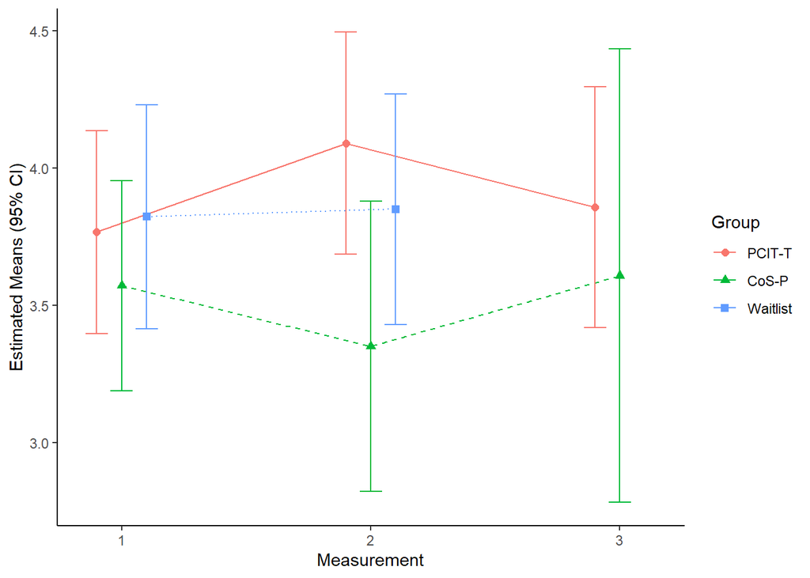

#### Hypothesis 1

We hypothesize that from baseline (‘T1’) to post-treatment/waitlist (‘T2’) there will be a gradient effect, whereby parent-child dyads who receive PCIT-T will show the greatest gains and parent-child dyads who receive no treatment will show the least gains. For the outcome, then, the null hypothesis is:

$H_0: \text {mean change}(\text{PCIT-T}) = \text {mean change}(\text{CoS-P}) = \text {mean change}(\text{Waitlist})$ $H_A: \text {mean change}(\text{PCIT-T}) > \text {mean change}(\text{CoS-P}) > \text {mean change}(\text{Waitlist})$

This is a joint hypothesis test.

First, confirming that the ordering of the means is as hypothesized:

```
## group = 1:
##  contrast estimate    SE   df t.ratio p.value
##  1 - 2     -0.3232 0.192 79.3  -1.683  0.2181
##  1 - 3     -0.0902 0.211 81.0  -0.429  0.9038
##  2 - 3      0.2330 0.217 77.0   1.072  0.5342
##
## group = 2:
##  contrast estimate    SE   df t.ratio p.value
##  1 - 2      0.2210 0.257 92.0   0.860  0.6665
##  1 - 3     -0.0366 0.411 90.9  -0.089  0.9956
##  2 - 3     -0.2576 0.421 82.7  -0.612  0.8140
##
## group = 3:
##  contrast estimate    SE   df t.ratio p.value
##  1 - 2     -0.0269 0.205 80.8  -0.131  0.9906
##  1 - 3      nonEst    NA   NA      NA      NA
##  2 - 3      nonEst    NA   NA      NA      NA
##
## Degrees-of-freedom method: kenward-roger
## P value adjustment: tukey method for comparing a family of 3 estimates
```

```
##   (Intercept) group2 group3 time2 time3 group2:time2 group3:time2 group2:time3
## 1           0      0      0     0     0           -1            0            0
## 2           0      0      0     0     1            0            1            0
```

```
##
##   General Linear Hypotheses
##
## Linear Hypotheses:
##        Estimate
## 1 == 0   0.5442
## 2 == 0  -0.2060
##
## Global Test:
##       F DF1 DF2 Pr(>F)
## 1 1.509   2 151 0.2244
```

#### Hypothesis 2

There will be a gradient of size of change from T2 to T3 such that the change in the PCIT-T group > the change in the CoS-P group. This isn’t really a gradient; it’s just 1 hypothesis.

First, the change in PCITT and COSP from time 2 to time 3:

```
## group = 1:
##  contrast estimate    SE   df t.ratio p.value
##  1 - 2     -0.3232 0.192 79.3  -1.683  0.2181
##  1 - 3     -0.0902 0.211 81.0  -0.429  0.9038
##  2 - 3      0.2330 0.217 77.0   1.072  0.5342
##
## group = 2:
##  contrast estimate    SE   df t.ratio p.value
##  1 - 2      0.2210 0.257 92.0   0.860  0.6665
##  1 - 3     -0.0366 0.411 90.9  -0.089  0.9956
##  2 - 3     -0.2576 0.421 82.7  -0.612  0.8140
##
## group = 3:
##  contrast estimate    SE   df t.ratio p.value
##  1 - 2     -0.0269 0.205 80.8  -0.131  0.9906
##  1 - 3      nonEst    NA   NA      NA      NA
##  2 - 3      nonEst    NA   NA      NA      NA
##
## Degrees-of-freedom method: kenward-roger
## P value adjustment: tukey method for comparing a family of 3 estimates
```

```
##
##   Simultaneous Tests for General Linear Hypotheses
##
## Fit: lmer(formula = outcome ~ group * time + (1 | id), data = dat)
##
## Linear Hypotheses:
##        Estimate Std. Error z value Pr(>|z|)
## 1 == 0   0.4906     0.4724   1.038    0.299
## (Adjusted p values reported -- single-step method)
```

p>0.05, so we do not have enough evidence to suggest that the change from t2 to t3 in PCITT is greater than the change in COSP.

#### Residuals

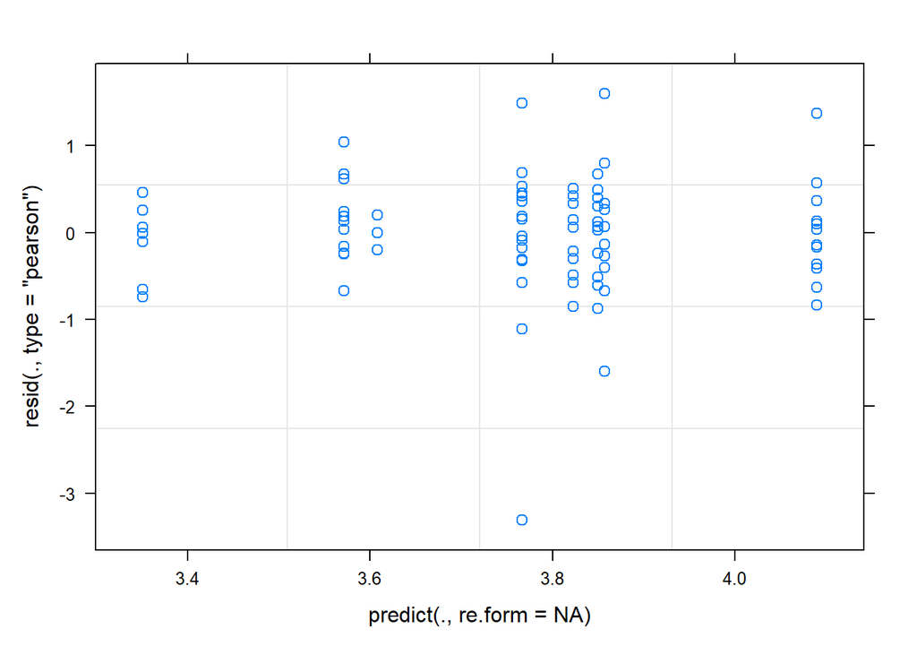

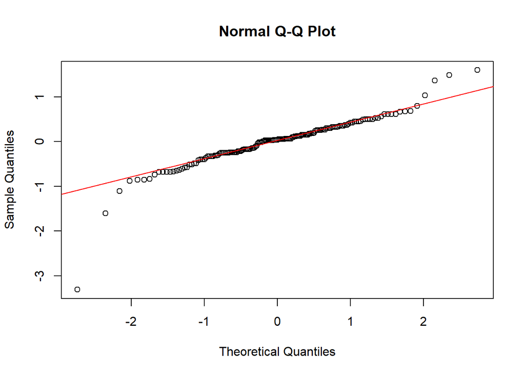

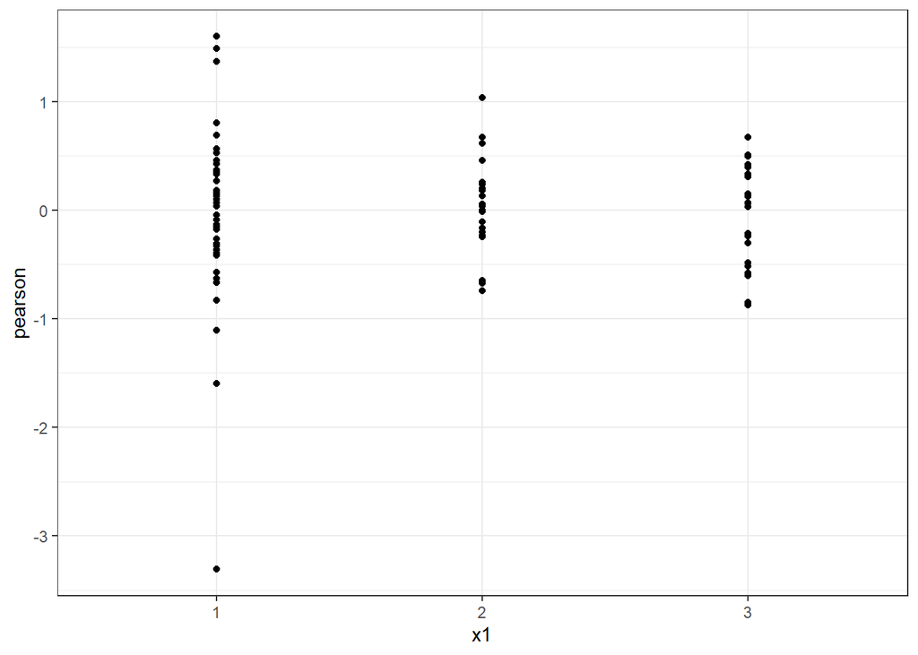

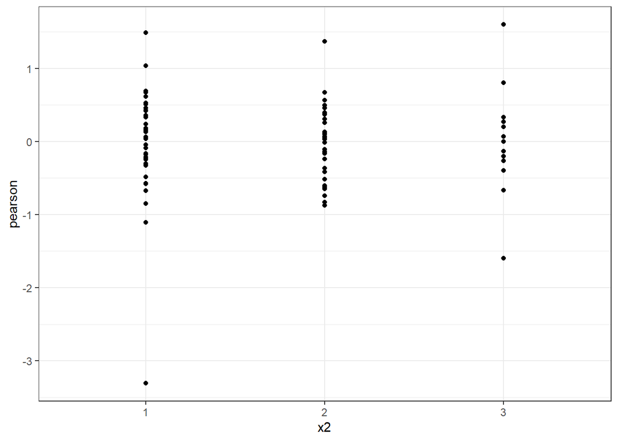

```r
rm(list = ls())
```